# Red Wine Exploration

### by Alina Zeshan

#### Project 4 of Data Analyst Degree

========================================================

Introduction

Dataset

Exploration of the Data

Univariate Plots

Univariate Analysis

Bivariate Plots Section

Bivariate Analysis

Multivariate Plots Section

Multivariate Analysis

Final Plot

Reflection

> **Introduction**: In this report, Red Wine dataset will be explored. The chemical properties of the wine will be taken care of and their effect on the quality of the wine. We will see that which variable will effect most on the quality of the wine(RED). At least 3 wine experts rated the quality of each wine, providing a rating between 0 (very bad) and 10 (very excellent). 11 attributes of Wine were considered e-g sugar content, salt content, acidic content,density, pH etc . So lets get started.

### Dataset

Citation Request: This dataset is public available for research. The details are described in [Cortez et al., 2009]. Please include this citation if you plan to use this database:

P. Cortez, A. Cerdeira, F. Almeida, T. Matos and J. Reis. Modeling wine preferences by data mining from physicochemical properties. In Decision Support Systems, Elsevier, 47(4):547-553. ISSN: 0167-9236.

Available at: [@Elsevier] http://dx.doi.org/10.1016/j.dss.2009.05.016 [Pre-press (pdf)] http://www3.dsi.uminho.pt/pcortez/winequality09.pdf [bib] http://www3.dsi.uminho.pt/pcortez/dss09.bib

The dataset was taken from following [Dataset](https://s3.amazonaws.com/video.udacity-data.com/topher/2018/September/5babed58_data-set-options-explore-and-summarize-data-project/data-set-options-explore-and-summarize-data-project.pdf)

Data Explored. > **Exploration of the Data**:

##### To see the Structure of the dataframe i-e Number of rows and Columns, and the names of the variables.

Moreover Basic Statistical summary is as follows

```
## 'data.frame':    1599 obs. of  13 variables:
##  $ X                   : int  1 2 3 4 5 6 7 8 9 10 ...
##  $ fixed.acidity       : num  7.4 7.8 7.8 11.2 7.4 7.4 7.9 7.3 7.8 7.5 ...
##  $ volatile.acidity    : num  0.7 0.88 0.76 0.28 0.7 0.66 0.6 0.65 0.58 0.5 ...
##  $ citric.acid         : num  0 0 0.04 0.56 0 0 0.06 0 0.02 0.36 ...
##  $ residual.sugar      : num  1.9 2.6 2.3 1.9 1.9 1.8 1.6 1.2 2 6.1 ...
##  $ chlorides           : num  0.076 0.098 0.092 0.075 0.076 0.075 0.069 0.065 0.073 0.071 ...
##  $ free.sulfur.dioxide : num  11 25 15 17 11 13 15 15 9 17 ...
##  $ total.sulfur.dioxide: num  34 67 54 60 34 40 59 21 18 102 ...
##  $ density             : num  0.998 0.997 0.997 0.998 0.998 ...
##  $ pH                  : num  3.51 3.2 3.26 3.16 3.51 3.51 3.3 3.39 3.36 3.35 ...
##  $ sulphates           : num  0.56 0.68 0.65 0.58 0.56 0.56 0.46 0.47 0.57 0.8 ...
##  $ alcohol             : num  9.4 9.8 9.8 9.8 9.4 9.4 9.4 10 9.5 10.5 ...
##  $ quality             : int  5 5 5 6 5 5 5 7 7 5 ...
```

```
##        X          fixed.acidity   volatile.acidity  citric.acid
##  Min.   :   1.0   Min.   : 4.60   Min.   :0.1200   Min.   :0.000
##  1st Qu.: 400.5   1st Qu.: 7.10   1st Qu.:0.3900   1st Qu.:0.090
##  Median : 800.0   Median : 7.90   Median :0.5200   Median :0.260
##  Mean   : 800.0   Mean   : 8.32   Mean   :0.5278   Mean   :0.271
##  3rd Qu.:1199.5   3rd Qu.: 9.20   3rd Qu.:0.6400   3rd Qu.:0.420
##  Max.   :1599.0   Max.   :15.90   Max.   :1.5800   Max.   :1.000
##  residual.sugar     chlorides       free.sulfur.dioxide
##  Min.   : 0.900   Min.   :0.01200   Min.   : 1.00
##  1st Qu.: 1.900   1st Qu.:0.07000   1st Qu.: 7.00
##  Median : 2.200   Median :0.07900   Median :14.00
##  Mean   : 2.539   Mean   :0.08747   Mean   :15.87
##  3rd Qu.: 2.600   3rd Qu.:0.09000   3rd Qu.:21.00
##  Max.   :15.500   Max.   :0.61100   Max.   :72.00
##  total.sulfur.dioxide    density             pH          sulphates
##  Min.   :  6.00       Min.   :0.9901   Min.   :2.740   Min.   :0.3300
##  1st Qu.: 22.00       1st Qu.:0.9956   1st Qu.:3.210   1st Qu.:0.5500
##  Median : 38.00       Median :0.9968   Median :3.310   Median :0.6200
##  Mean   : 46.47       Mean   :0.9967   Mean   :3.311   Mean   :0.6581
##  3rd Qu.: 62.00       3rd Qu.:0.9978   3rd Qu.:3.400   3rd Qu.:0.7300
##  Max.   :289.00       Max.   :1.0037   Max.   :4.010   Max.   :2.0000
##     alcohol         quality
##  Min.   : 8.40   Min.   :3.000
##  1st Qu.: 9.50   1st Qu.:5.000
##  Median :10.20   Median :6.000
##  Mean   :10.42   Mean   :5.636
##  3rd Qu.:11.10   3rd Qu.:6.000
##  Max.   :14.90   Max.   :8.000
```

So our Data has Around 1600 observations and 13 Columns. One being a Quality Variable and First One is used for the Id (which will be dropped soon) other 11 variables define the factors on which Quality is dependent.

Moreover, Quality is shown as integer column, and it will be converted into categorical one as this is ordinal discrete variable which shows that the quality falls in which group.

Suprisingly, our dataset has quality ranging from 3 to 8, nono assign the value below 3, that is bad or above 8, that is very good wine.

# Univariate Plots Section

To get a basic visual knowledge of the dataset is to plot the histograms. as their are 12 variables but they can be easily grouped together like total sulpher dioxide, free sulpher dioxide and sulphates. so fot=r the eadse they will be grouped together.

##### first group of Sulphates

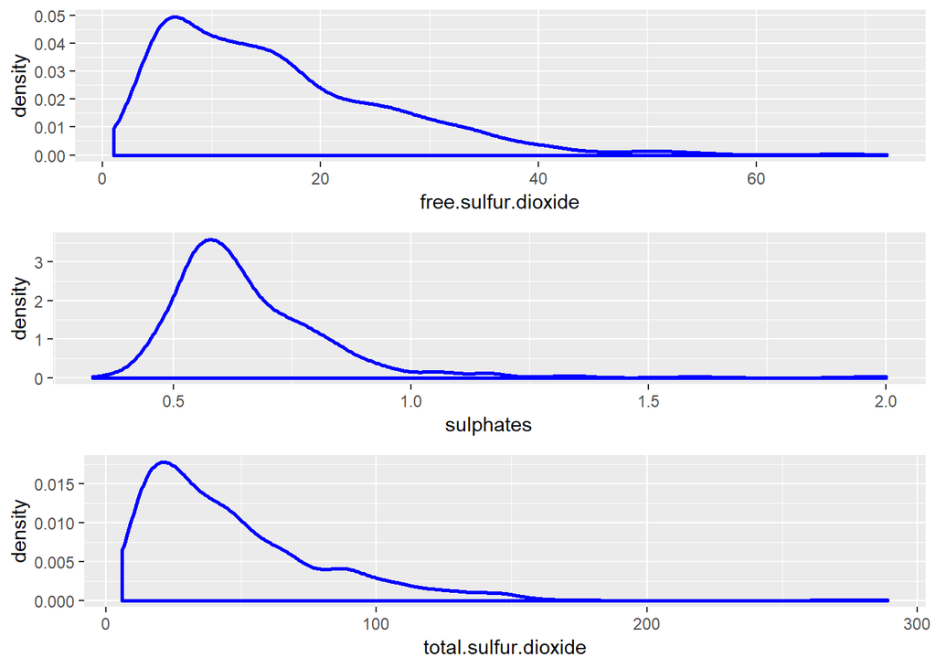

As it can be seen from above grid that the plots are right skewed that is a long right sided tail.There is a little data on right side so again we will plot them with removing the top 1% of the Data.

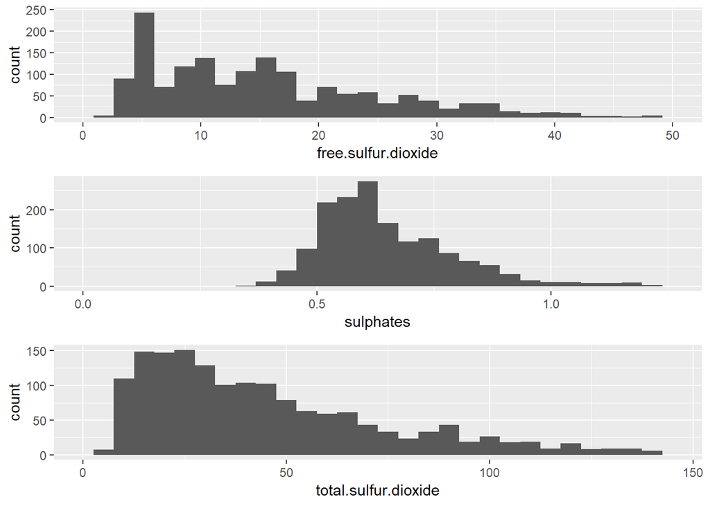

It can be seen that after removing top 1% of the data , the bulk of data lies in center, Sulphates exhibits normal distribution, free sulfur dioxide is spread overall, total sulfur dioxide is still right skewed.

##### Second group of acidic properties

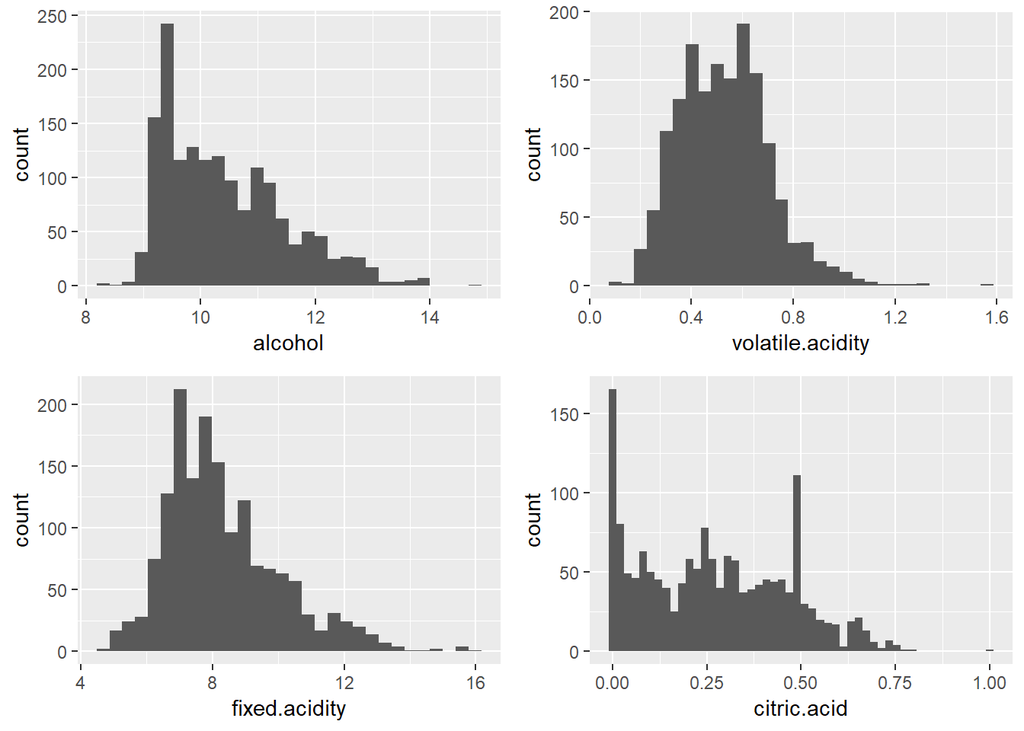

THese plots seems reasonable normally distributed, With slight Adjustment of the Bin Size for citric Acid, it can be seen that it exhibits Bimodal distribution. ITs different and will be taken care of ahead.Alcohol has a peak it can be seen as bimodal distribution.

##### Third group of remaining properties

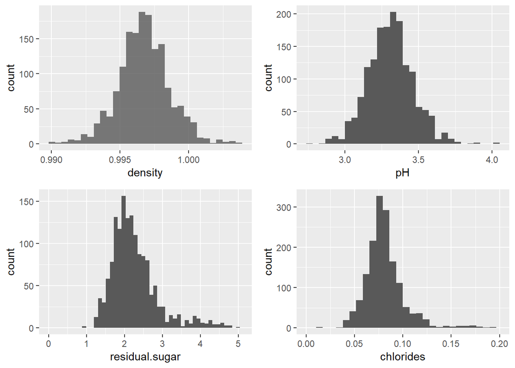

Top 5% are removed in residual sugar plot as outliers.And then it shows a better picture. Remaining Plots are reasonably Normally distibuted.

##### Bar plot for quality

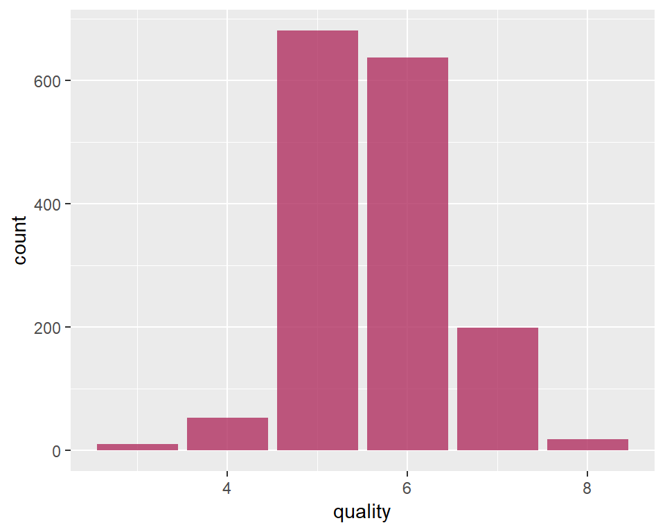

As it can be seen that mostly the wines collected are of mid range i-e 5 and 6 with fewer of bad quality and excellent quality. I wonder what can make a wine excellent and what can make it bad.but the point is that extremes of the quality are missing. HEnce It would be easier to group them fro example combining 3 and 4 as a single group and 7 and 8 as another single group. 5 and 6 will be treted as they are.

```
##
##           bad       average above average     very good
##            63           681           638           217
```

##### Creating New Variable

In addition to individual variables , it is alos benificial to draw some ratio, for example of sugar and alcohol, as sugar content is increased with the higher content of the sugar.

Moreover density and volatile acid is also related.

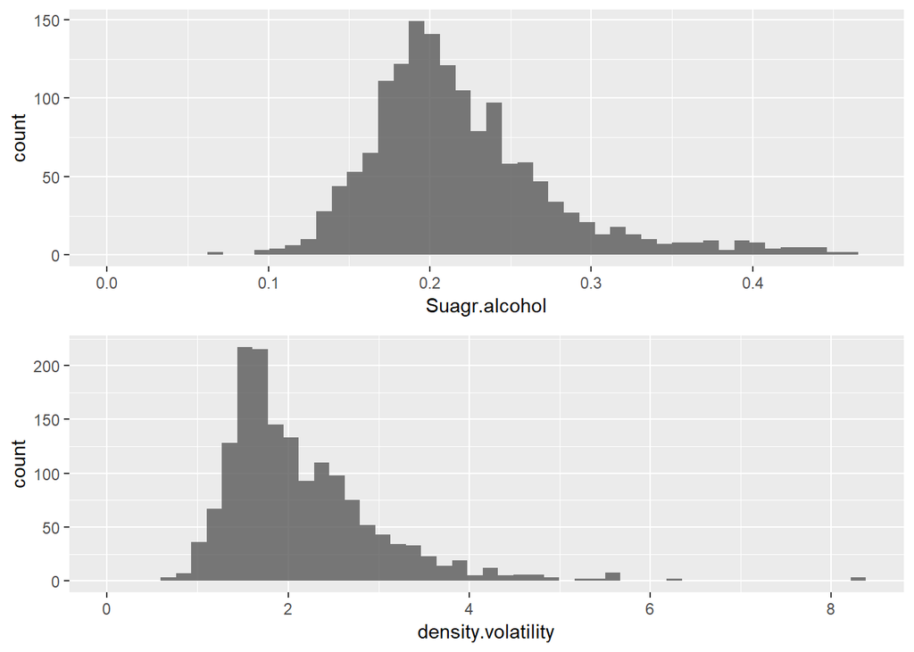

# Univariate Analysis

### What is/are the main feature(s) of interest in your dataset?

- Quality It is our main feature of Interest as all the remaining variables are used to define the quality of Wine as perceived by the Wine Experts.

### What other features in the dataset do you think will help support your investigation into your feature(s) of interest?

-Alcholhol -citric Acid -Volatile Acidity -Suagr and alcohol ratio -Salt content(Chlorides) -Sulphates

### Did you create any new variables from existing variables in the dataset?

Yes. first of all Quality variable is converted into grouped bins, suagr and alcohol ratio was created by using residual sugar content variable and alcohol variable. Finally density and volatile acidity ratio was created fom the density variable and volatile acidity variable.

### Of the features you investigated, were there any unusual distributions? Did you perform any operations on the data to tidy, adjust, or change the form of the data? If so, why did you do this?

In residual sugar, top 5% are removed to avoid overplotting and outliers.

# Bivariate Plots Section

NOw we are ready to explore the relationships between different variables. so we will use box plots and scatter plots for bivariate analysis. box plot will be used for the categorical vs numerical variable but scateer plots will be used for numerical variables

First i will use scatter plot matrices for visualizing fewer variables at a time

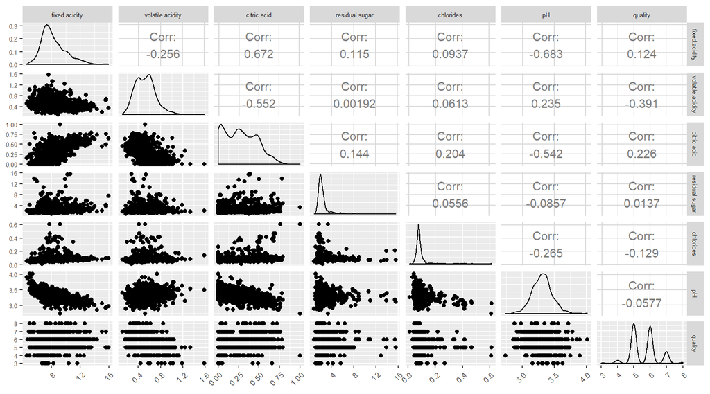

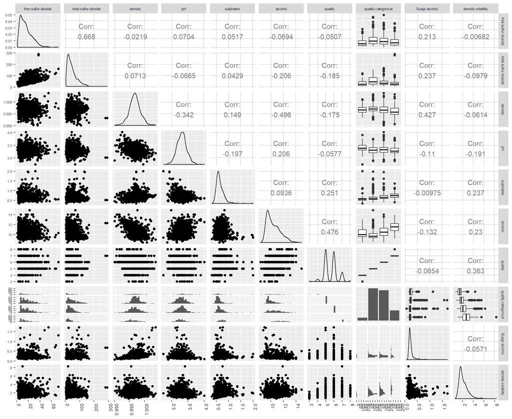

As it can be seen from above plots that following variables have good correlation with the quality of the wines alcohol has 0.47 correlation which is good. Volatile Acidity has a correlation coefficient of -0.391 Density and Volatilty ratio has 0.363 correlation with the quality.

Alcohol has positive effect on the quality of wine. As it can be seen that bad quality wines have low content of alcohol but a higher quality of wines have higher quantity of alcohol. I want to use box plot for clear understanding

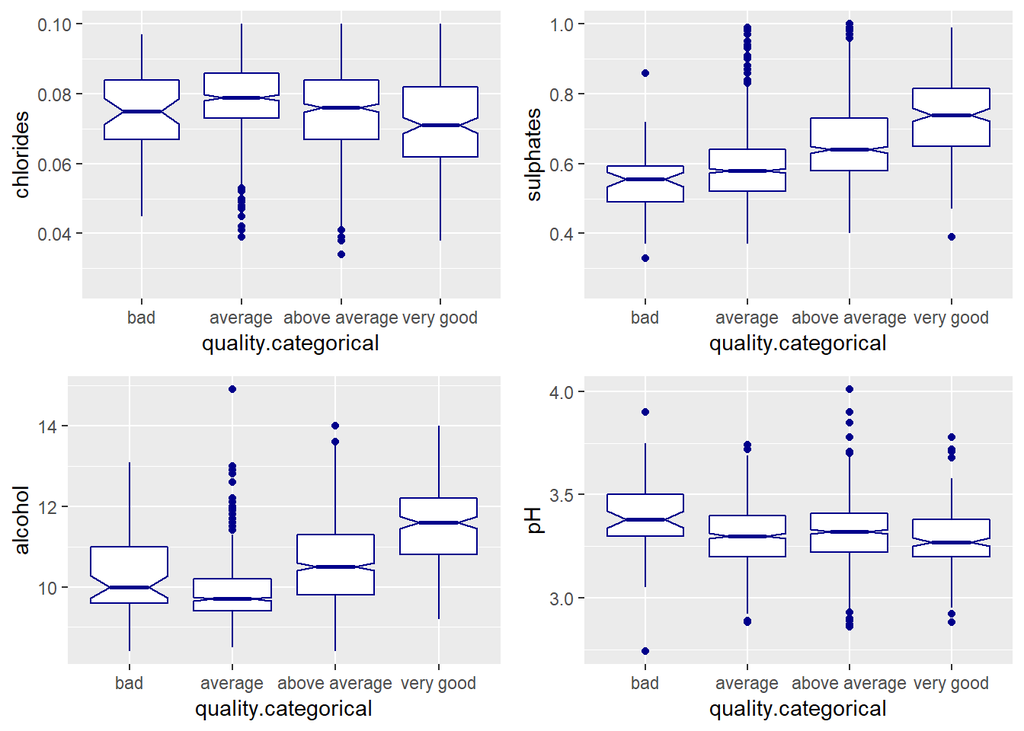

Chlorides and Alcohol have variable effect on the quality of Wines. Sulphates have clearly Positive efeect on the quality of the Wine. Ph is almost inversely related.As I have chemistry background, i thought it was obvious that Bad Quality wines have higher pH that is they Are more basic in nature rather acidic.

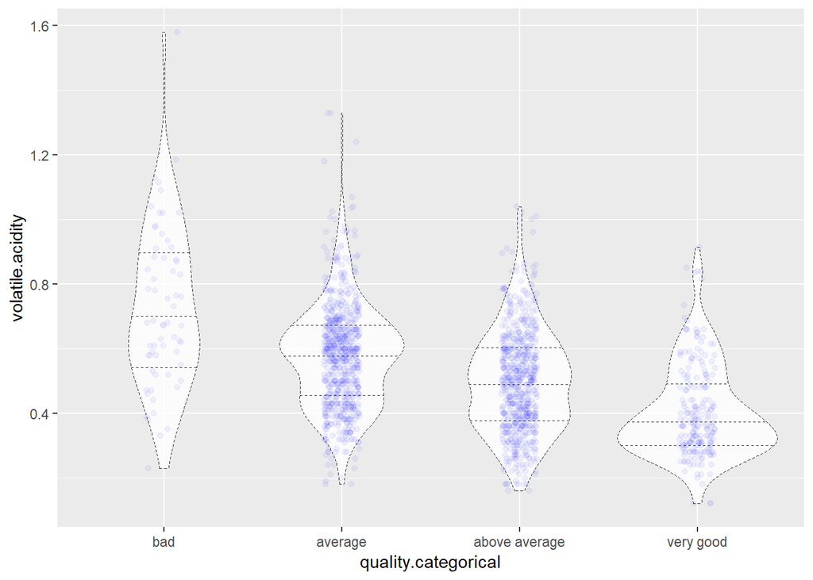

It is a compact display of a continous distribution. As expected, higher volatility leads to the bad quality of the wine, as it leaves the bad odour and taste after sometime.As volatile acidity incrreases, the quality of the Wine decreases.

One more correlation is seen between the ratio i created that is sugar alcohol ratio and the density. so lets plot them

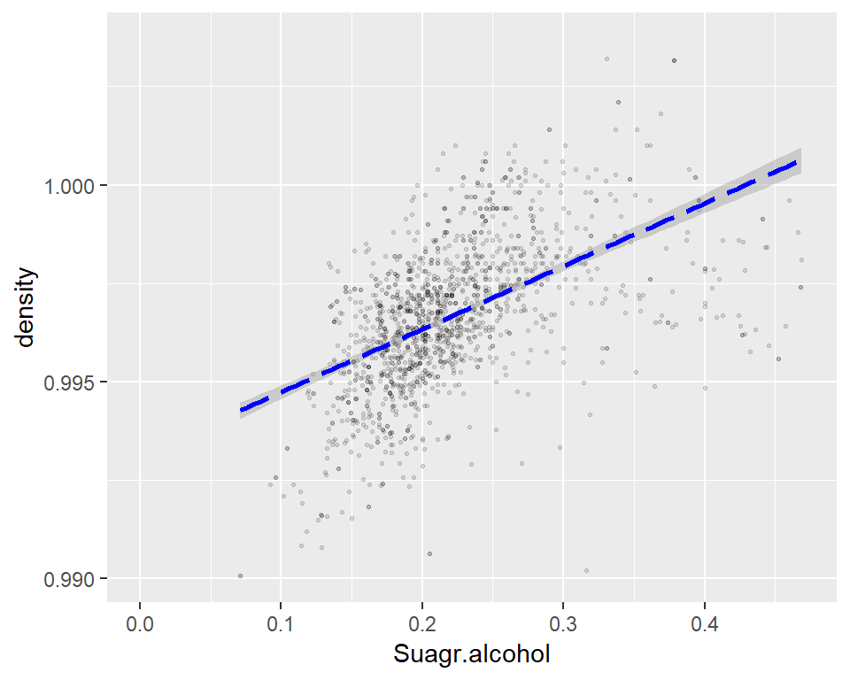

Great, This shows that they are directly realted.Beacuse of the fact that when sugar content is increased, so does the alcohol content, which results in the increase in density.

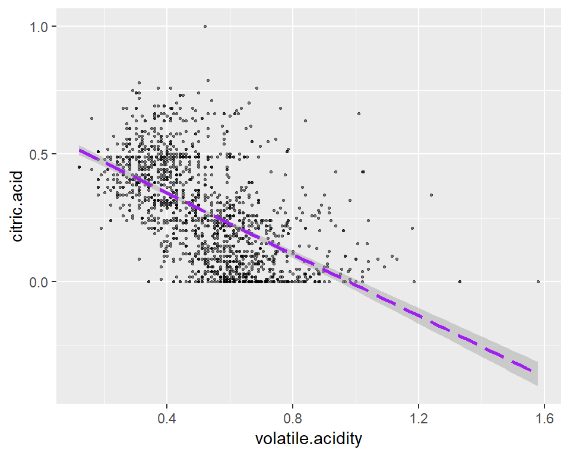

Interestingly, citric Acid and Volatility are inversely related.

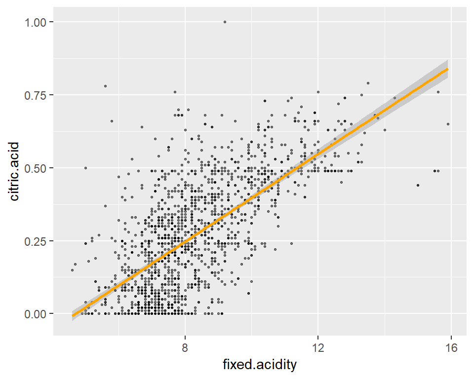

And more interestingly, fixed acidity and citric acid are directly related.

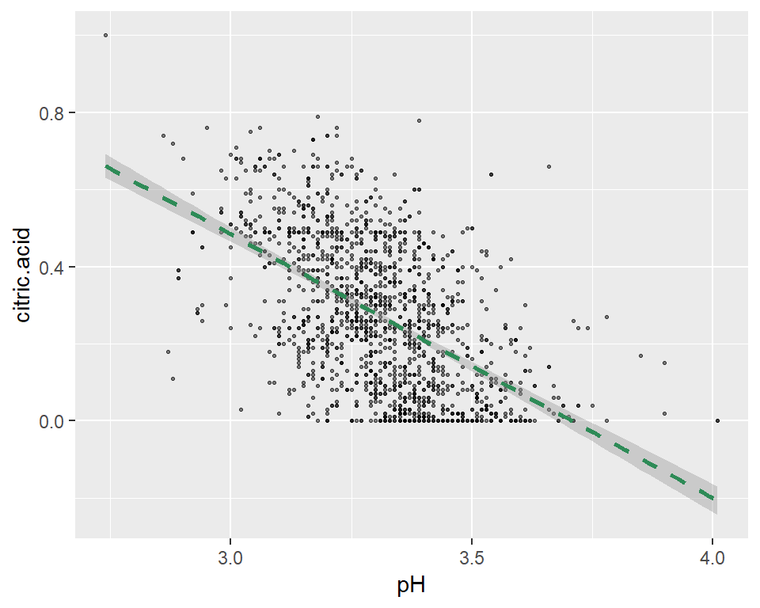

pH and citric acid are also inversely related to each other.

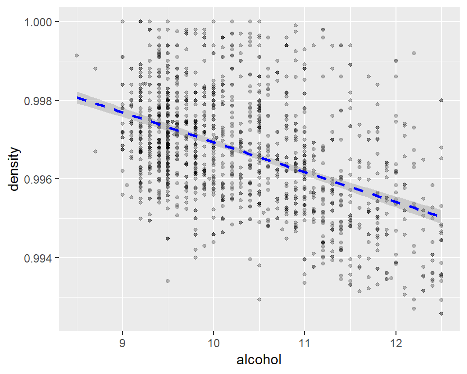

Here it is evedient that alcohol and density is inveresely related. as the chemical properties of the alcohol are suggestive of this behaviour that the density decreases as the alcohol content increases in the wine.

# Bivariate Analysis

### Did you observe any interesting relationships between the other features (not the main feature(s) of interest)?

plota show some interesting and surprising behaviour but mostly their relation is obvious if considered their inherent chemical properties citric acid and pH are inveresly related. Fixed acidity and citric acid are directly related. Density and alcohol are inversely related

# Multivariate Plots Section

Now Multi variable Plots will be visualized. i will take help from my bivariate plots and quality willbe added as a layer.

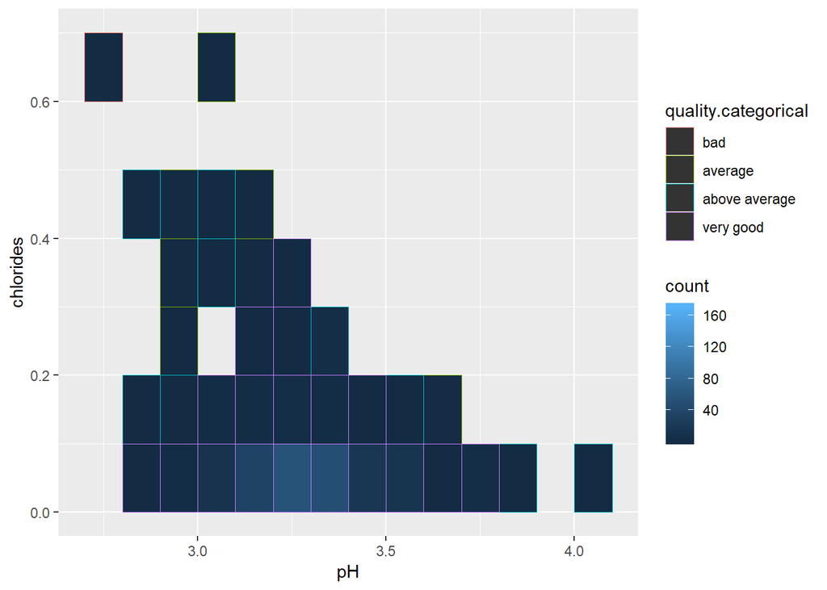

we can say t hat high chlorides and low pH is the signature of bad wine quality. though good quality Wines have wide spread pH area but they almost can not have high chloride content

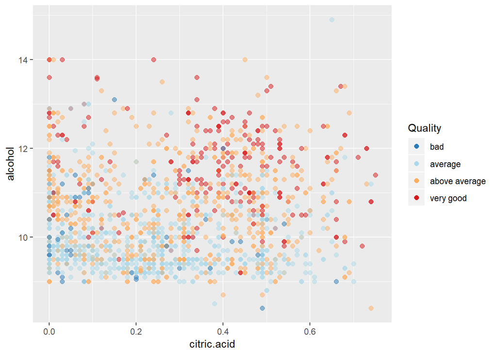

This graph is very interesting, which shows the linear relation of the quality of the Red wine with the alcohol and the citric acid Citric Acid and Alchohol have a great influence on the quality of the wine.Better wine that is above 6 is scattered with higher content of citric acid and alchohol.While the Quality of wine will be decreased if the content of Alcohol and citric acid is decreased.

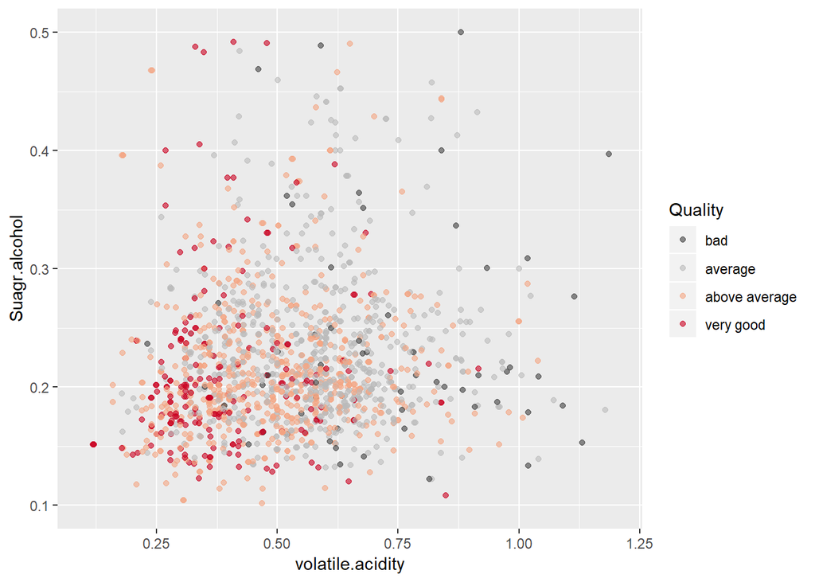

Interestingly volatile acidity is inveresely related to the quality of the Wine.as we have already discusse dthat higher volatility leads to unpleasant smell and taste of vineger. Sugar and alcohol ration does not have any impact

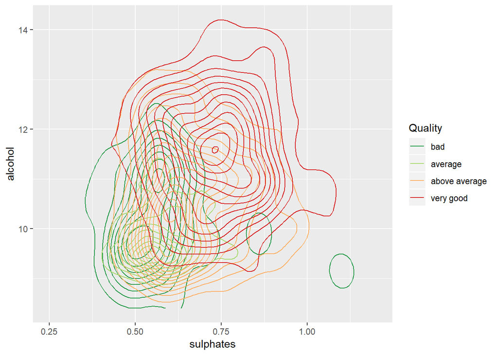

This density plot is very informative showing the relation of the sulphates and alchohol with the qualty of the wine. they both are directly related with the Quality.

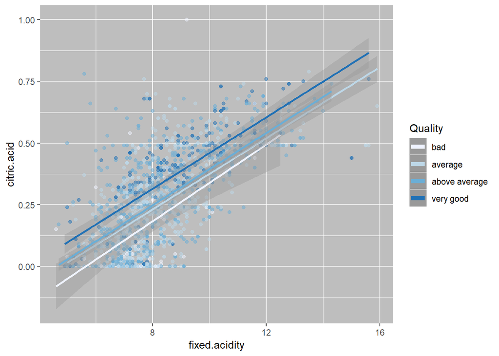

This is really informative Plot showing the relation of the quality of Wine with the Citric Acid and fixd acidity rather taht volatile. and they both area sign of good quality. as they lead to the sweet pleasant taste without giving residual unpleasant taste.

# Multivariate Analysis

### Talk about some of the relationships you observed in this part of the investigation. Were there features that strengthened each other in terms of looking at your feature(s) of interest?

It can be noticed that fixed acidity, alcohol content has direct relation with the quality of the wine

# Final Plots and Summary

### Plot One

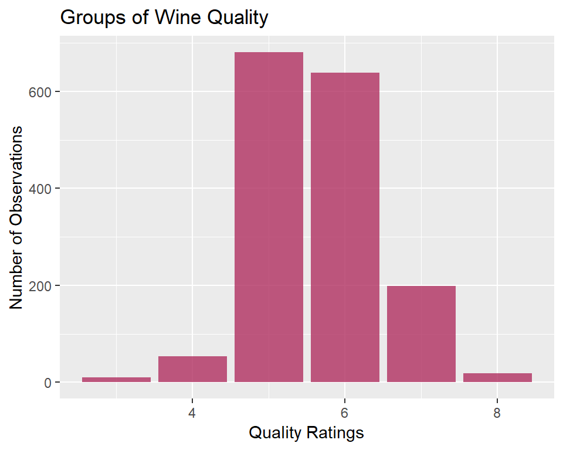

### Description One

This plot is very Important in the whole exploratory anlysis. I must say that after this grammer of graphics , i realized the ultimate need of grouping the data into combined groups and then the whole lot of plots became more descriptive and understandable. As we can clearly see that data at extremes were almost missing and most, rather a good heavy chunk of data is around the center that is average.By combining the last two bins on both extremes, it became reasonable comparatively.

### Plot Two

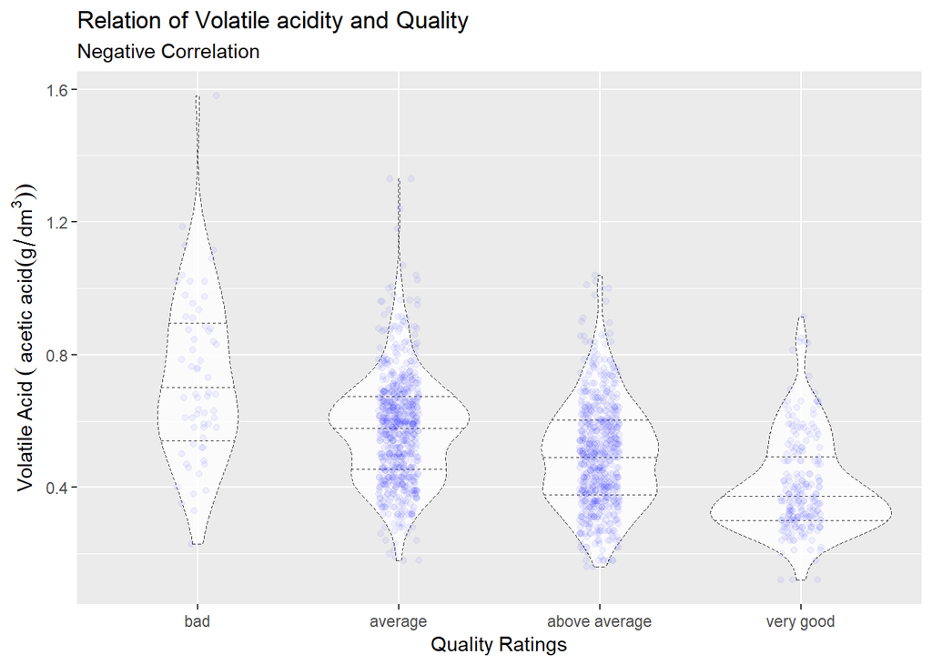

### Description Two

This Single piece of plot is good to explain the relation of the volatile acidity with the Quality of the Wine. This is a combination of Distribution plot and box plot showing the quantiles as well. This show sthat higher the volatile Acid, lower will be the quality of the Wine.

### Plot Three

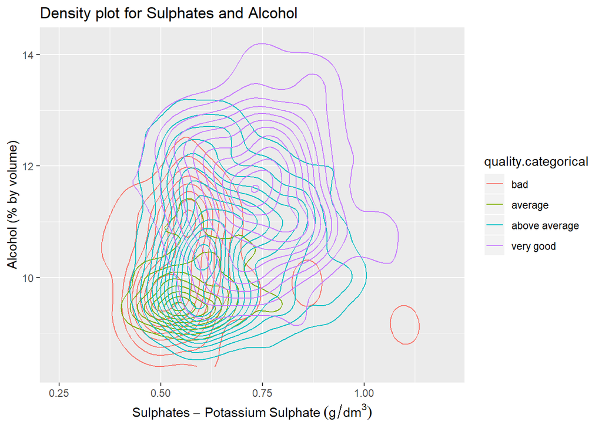

### Description Three

This Plot shows the relation of the Alohol and sulphates to the quality of the wine. as it is clear in thi splot that higher qualty wines occupy the higher range of both variables. while low quality exhibits the feature of low content of alcohol and sulphates.

## Reflection

It was an interesting dataset regarding the Chemical properties of the Red Wine and Deciding wheather they are of good quality or Bad quality wine. The difficulty which I faced in exploring the data is finding relations of the variables with the qualtity directly. But once i categorize them, things become simpler comparatively.

It was very well formulated project as it used all the basic knowledge we have gained so far regarding R. moreover it teaches us to explore more options for the plots and the different ways to explore the DAta.

I enjoyed most with playing aroung the plots, their types and specially colors. though sometimes it was quite hard to infer any results from the basis help of the R but sometimes googl around and watching few youtube tutorials helps a lot.

To get comfortable with R studio needs a little time and effort but once it was done, its fun to explore around and to use as many options as possible.

This data would be better in deciding the relation of different chemical properties if there would be more data on the extremes. This Data has lack the points of extremes , which leads to non-decisive nature of Data.